# AI Hardware Analysis

# Data Processing

To accurately synthesize this data, a many-to-one relational join is required. This function standardizes names across all datasets to ensure clean joins.

```r
clean_gpu_string <- function(name_col) {
  name_col %>%
    str_to_lower() %>%
    # Remove brand fluff
    str_remove_all("\\b(msi|asus|gigabyte|zotac|evga|sapphire|powercolor|pny)\\b") %>%
    str_remove_all("\\b(nvidia|amd|ati|founders|collectors|anniversary|frontier|edition|50th)\\b") %>%
    # Destroy hyphens followed by numbers (fixes the " - 512" issue)
    str_remove_all("-\\s*[0-9]+") %>%
    # Target VRAM (3gb), Wattage (75w), minor variants (g5, ddr4), and specific editions (se, oem, lhr, x2, sff)
    str_remove_all("\\b([0-9]+gb|[0-9]+w|g[56]|ddr[0-9]|se|oem|lhr|x2|sdi|sff)\\b") %>%
    # Remove the word "series" from SHS
    str_remove_all("\\bseries\\b") %>%
    # Squish multiple spaces down to a single space
    str_squish() %>%
    # Handle AMD Radeon HD groupings (e.g., changes "radeon hd 7750" to "radeon hd 7700")
    str_replace_all("radeon hd ([0-9]{2})[0-9]{2}[a-z]*", "radeon hd \\100") %>%
    # Handle AMD R7/R9 Series groupings (e.g., changes "r9 290x" to "r9 200")
    str_replace_all("r9 2[0-9]{2}[a-z]*", "r9 200") %>%
    str_replace_all("r9 3[0-9]{2}[a-z]*", "r9 300") %>%
    str_replace_all("r7 2[0-9]{2}[a-z]*", "r7 200") %>%
    str_replace_all("r7 3[0-9]{2}[a-z]*", "r7 300")
}
```

We load the five disparate datasets required for the high-dimensional dataset.

```r
# Assuming files are in the working directory
video_cards <- read_csv("data/video-card.csv") %>% clean_names()
gpu_benchmarks <- read_csv("data/GPU_benchmarks_v7.csv") %>% clean_names()
ml_hardware <- read_csv("data/ml_hardware.csv") %>% clean_names()
shs <- read_csv("data/shs.csv") %>% clean_names()
ppi_data <- read_csv("data/PCU334413334413.csv") %>% clean_names()
```

#### Process Retail Video Cards (video-card.csv)

Keeping NA/0 prices, dropping irrelevant string columns

```r
video_cards_clean <- video_cards %>%
  select(-name, -color, -length) %>%
  mutate(chipset = clean_gpu_string(chipset)) %>%
  group_by(chipset) %>%
  summarise(
    avg_retail_price = mean(price, na.rm = TRUE),
    vram_capacity = max(memory, na.rm = TRUE),
    core_clock = max(core_clock, na.rm = TRUE),
    boost_clock = max(boost_clock, na.rm = TRUE)
  ) %>%
  # Catch -Inf (from max) and NaN (from mean) and safely convert back to NA
  mutate(
    across(c(vram_capacity, core_clock, boost_clock), ~na_if(., -Inf)),
    avg_retail_price = na_if(avg_retail_price, NaN)
  ) %>%
  distinct(chipset, .keep_all = TRUE)
```

#### Process Traditional Benchmarks (GPU_benchmarks_v7.csv)

Keeping price, dropping mobile segments

```r
benchmarks_clean <- gpu_benchmarks %>%
  mutate(
    # Create a temporary lowercase name for easy regex searching
    lower_name = str_to_lower(gpu_name),
    # Intelligently reclassify 'Unknown' (and correct mislabeled) GPUs
    category = case_when(
      # If it has laptop terminology, force it to Mobile
      str_detect(lower_name, "mobile|max-q|laptop|notebook") ~ "Mobile",
      # If it has enterprise/AI terminology, force it to Workstation
      str_detect(lower_name, "quadro|tesla|firepro|radeon pro|rtx a[0-9]") ~ "Workstation",
      # If it's still 'Unknown' after the above checks, safely assume it's a Desktop consumer card
      category == "Unknown" ~ "Desktop",
      # Otherwise, keep the original valid classification
      TRUE ~ category
    )
  ) %>%
  # Now apply the strict filter with confidence that the data is accurately tagged
  filter(category %in% c("Desktop", "Workstation")) %>%
  mutate(
    chipset = clean_gpu_string(gpu_name),
    chipset = str_replace(chipset, "radeon rx 570x", "radeon rx 570")
  ) %>%
  select(chipset, category, g3dmark, g2dmark, tdp, benchmark_price = price) %>%
  distinct(chipset, .keep_all = TRUE)
```

#### Process Steam Hardware Survey (shs.csv)

Keeping 0 percentages, filtering out CPUs/OS metrics

```r
shs_clean <- shs %>%
  filter(category == "Video Card Description") %>%
  # Drop laptop chips (mobility/mobile) and integrated CPU graphics (intel)
  filter(!str_detect(str_to_lower(name), "mobility|mobile|intel")) %>%
  mutate(
    date = ymd(date),
    month_year = floor_date(date, "month"),
    chipset = clean_gpu_string(name)
  ) %>%
  # Apply strict timeline filter
  filter(month_year >= ymd("2009-01-01") & month_year <= ymd("2025-12-31")) %>%
  select(month_year, chipset, percentage)
```

#### Process AI Architectural Specs (ml_hardware.csv)

Filtering for GPUs only. Keeping all numeric specs, dropping irrelevant string columns

```r
ml_hardware_clean <- ml_hardware %>%
  filter(type == "GPU") %>%
  mutate(chipset = clean_gpu_string(hardware_name)) %>%
  select(
    chipset,
    ml_release_price = matches("release_price"),
    ml_memory = matches("memory_bytes"),
    ml_tdp = matches("tdp"),
    fp32_flops = matches("fp32_single"),
    ml_base_clock = matches("base_clock"),
    ml_boost_clock = matches("boost_clock"),
    tensor_cores,
  ) %>%
  mutate(
    across(
      c(ml_memory, fp32_flops),
      ~ .x / 1e9
    )
  ) %>%
  distinct(chipset, .keep_all = TRUE)
```

Add missing cards’ informations manually based on producers’ websites and Wikipedia

```r
missing_gpus <- tibble(
  chipset = c(
    "geforce rtx 5050", "geforce rtx 5060", "geforce rtx 5060 ti", "geforce rtx 5070",
    "geforce rtx 5070 ti", "geforce rtx 5080", "geforce rtx 5090",
    "rtx 4000 ada generation", "rtx 5000 ada generation",
    "radeon rx 9060 xt", "radeon rx 9070", "radeon rx 9070 xt",
    "arc b570", "arc b580", "arc a310", "arc a380", "arc a580", "arc a750", "arc a770",
    "geforce rtx 4060", "geforce rtx 4060 ti", "geforce rtx 4070", "geforce rtx 4070 super",
    "geforce rtx 4070 ti", "geforce rtx 4070 ti super", "geforce rtx 4080 super",
    "radeon rx 7600", "radeon rx 7600 xt", "radeon rx 7700 xt", "radeon rx 7800 xt",
    "radeon rx 7900 gre", "radeon rx 7900 xt",
    "geforce rtx 3050", "geforce rtx 3060", "geforce rtx 3060 ti", "geforce rtx 3070",
    "geforce rtx 3070 ti", "geforce rtx 3080", "geforce rtx 3080 ti", "geforce rtx 3090", "geforce rtx 3090 ti",
    "geforce rtx 2060", "geforce rtx 2060 super", "geforce rtx 2070", "geforce rtx 2070 super",
    "geforce rtx 2080", "geforce rtx 2080 super", "geforce rtx 2080 ti",
    "radeon rx 6650 xt", "radeon rx 6750 xt", "radeon rx 6950 xt",
    "rtx 2000 ada generation", "rtx 2000e ada generation", "rtx 4500 ada generation",
    "radeon pro w7500", "radeon pro w7600", "radeon pro w7700", "radeon pro w7800", "radeon pro w7900",
    "radeon pro w6600", "radeon pro w6800",
    "radeon rx 6500 xt", "radeon rx 6600", "radeon rx 6600 xt", "radeon rx 6700 xt",
    "radeon rx 6800", "radeon rx 6800 xt", "radeon rx 6900 xt"
  ),

  ml_release_price = c(
    249, 299, 429, 549, 749, 999, 1999,
    1250, 4000,
    399, 549, 599,
    219, 249, 110, 139, 179, 249, 329,
    299, 399, 599, 599, 799, 799, 999,
    269, 329, 449, 499, 549, 899,
    249, 329, 399, 499, 599, 699, 1199, 1499, 1999,
    349, 399, 499, 499, 699, 699, 999,
    399, 549, 1099,
    625, 625, 2250,
    429, 599, 999, 2499, 3999,
    649, 2249,
    199, 329, 379, 479, 579, 649, 999
  ),

  ml_memory = c(
    8, 8, 16, 12, 16, 16, 32,
    20, 32,
    16, 16, 16,
    10, 12, 4, 6, 8, 8, 16,
    8, 8, 12, 12, 12, 16, 16,
    8, 16, 12, 16, 16, 20,
    8, 12, 8, 8, 8, 10, 12, 24, 24,
    6, 8, 8, 8, 8, 8, 11,
    8, 12, 16,
    16, 16, 24,
    8, 8, 16, 32, 48,
    8, 32,
    4, 8, 8, 12, 16, 16, 16
  ),

  ml_tdp = c(
    130, 145, 180, 250, 300, 360, 575,
    130, 250,
    160, 220, 304,
    150, 190, 75, 75, 185, 225, 225,
    115, 160, 200, 220, 285, 285, 320,
    165, 190, 245, 263, 260, 300,
    130, 170, 200, 220, 290, 320, 350, 350, 450,
    160, 175, 175, 215, 215, 250, 250,
    180, 250, 335,
    70, 50, 210,
    70, 130, 190, 260, 295,
    130, 250,
    107, 132, 160, 230, 250, 300, 300
  ),

  fp32_flops = c(
    13.17, 19.18, 23.70, 30.84, 43.94, 56.28, 104.80,
    26.70, 65.30,
    25.64, 36.13, 48.66,
    12.70, 13.67, 3.07, 4.09, 10.42, 14.64, 17.20,
    15.11, 22.06, 29.15, 35.48, 40.09, 44.10, 52.22,
    21.75, 22.57, 35.17, 37.32, 43.01, 51.48,
    9.10, 12.74, 16.20, 20.31, 21.75, 29.77, 34.10, 35.58, 40.00,
    6.45, 7.18, 7.46, 9.06, 10.07, 11.15, 13.45,
    10.79, 13.31, 23.65,
    12.0, 8.9, 39.6,
    12.2, 16.6, 28.3, 45.3, 61.3,
    10.4, 26.7,
    5.77, 8.93, 10.60, 13.21, 16.17, 20.74, 23.04
  ),

  tensor_cores = c(
    80, 120, 144, 192, 280, 336, 680,
    192, 400,
    64, 112, 128,
    144, 160, 96, 128, 384, 448, 512,
    96, 136, 184, 224, 240, 264, 320,
    64, 64, 108, 120, 160, 168,
    80, 112, 152, 184, 192, 272, 320, 328, 336,
    240, 272, 288, 320, 368, 384, 544,
    32, 40, 80,
    88, 88, 240,
    28, 32, 48, 70, 96,
    28, 60,
    16, 28, 32, 40, 60, 72, 80
  )
)
# Bind the missing cards BEFORE the main dataset so our complete specs overwrite any NAs
ml_hardware_clean <- missing_gpus %>%
  bind_rows(ml_hardware_clean) %>%
  distinct(chipset, .keep_all = TRUE)
```

#### Process Baseline Inflation Control (FRED’s PCU334413334413.csv)

Filtering out historical data that precedes the SHS timeline

```r
min_shs_date <- min(shs_clean$month_year, na.rm = TRUE)
ppi_clean <- ppi_data %>%
  rename(date = observation_date, semi_ppi = pcu334413334413) %>%
  mutate(
    date = ymd(date),
    month_year = floor_date(date, "month")
  ) %>%
  # Apply strict timeline filter
  filter(month_year >= ymd("2009-01-01") & month_year <= ymd("2025-12-31")) %>%
  select(month_year, semi_ppi)
```

Write the Clean Datasets to CSV

```r
write_csv(video_cards_clean, "data/video_cards_clean.csv")
write_csv(benchmarks_clean, "data/benchmarks_clean.csv")
write_csv(shs_clean, "data/shs_clean.csv")
write_csv(ml_hardware_clean, "data/ml_hardware_clean.csv")
write_csv(ppi_clean, "data/ppi_clean.csv")
```

#### Prepare and export the GPUs Dictionary

```r
# Full Join
hardware_dictionary <- video_cards_clean %>%
  full_join(benchmarks_clean, by = "chipset") %>%
  full_join(ml_hardware_clean, by = "chipset") %>%
# Category Imputation
  mutate(
    # Fixes NA categories for newer cards not in the benchmark dataset
    category = case_when(
      !is.na(category) ~ category, # Keep existing valid categories
      str_detect(chipset, "geforce rtx|gtx|rx|radeon hd|arc a|arc b|geforce") ~ "Desktop", # Consumer gaming tags
      str_detect(chipset, "pro|quadro|tesla|instinct") ~ "Workstation", # Enterprise tags
      TRUE ~ "Workstation" # Default remaining unknowns to Workstation
    ),
# Consolidate Overlapping Columns (Averaging)
    # Convert all 0 values to NA across overlapping columns
    across(
      c(avg_retail_price, benchmark_price, ml_release_price,
        core_clock, ml_base_clock,
        boost_clock, ml_boost_clock,
        tdp, ml_tdp,
        vram_capacity, ml_memory),
      ~na_if(., 0)
    ),
    # Calculate Unified Means (suppressWarnings hides NaN warnings if all are NA)
    unified_price = suppressWarnings(rowMeans(cbind(avg_retail_price, benchmark_price, ml_release_price), na.rm = TRUE)),
    unified_base_clock = suppressWarnings(rowMeans(cbind(core_clock, ml_base_clock), na.rm = TRUE)),
    unified_boost_clock = suppressWarnings(rowMeans(cbind(boost_clock, ml_boost_clock), na.rm = TRUE)),
    unified_tdp = suppressWarnings(rowMeans(cbind(tdp, ml_tdp), na.rm = TRUE)),
    unified_memory = suppressWarnings(rowMeans(cbind(vram_capacity, ml_memory), na.rm = TRUE))
  ) %>%
  # Convert any mathematical NaN results back to proper NA
  mutate(across(starts_with("unified_"), ~na_if(., NaN))) %>%
  # Drop the original redundant columns
  select(
    -avg_retail_price, -benchmark_price, -ml_release_price,
    -core_clock, -ml_base_clock,
    -boost_clock, -ml_boost_clock,
    -tdp, -ml_tdp,
    -vram_capacity, -ml_memory
  )
```

#### Regression Imputation for Missing Benchmarks

```r
# Train a simple model on GPUs that have both g3dmark and fp32_flops
g3d_model <- lm(g3dmark ~ fp32_flops, data = filter(hardware_dictionary, !is.na(g3dmark) & !is.na(fp32_flops)))
g2d_model <- lm(g2dmark ~ fp32_flops, data = filter(hardware_dictionary, !is.na(g2dmark) & !is.na(fp32_flops)))

hardware_dictionary <- hardware_dictionary %>%
  mutate(
    predicted_g3d = predict(g3d_model, newdata = .),
    predicted_g2d = predict(g2d_model, newdata = .),
    # If g3dmark or g2dmark are missing (new cards), fill it with the prediction based on FLOPs
    g3dmark = case_when(
      is.na(g3dmark) & !is.na(fp32_flops) ~ predicted_g3d,
      TRUE ~ g3dmark
    ),
    g2dmark = case_when(
      is.na(g2dmark) & !is.na(fp32_flops) ~ predicted_g2d,
      TRUE ~ g2dmark
    )
  ) %>%
  # Drop the temporary prediction columns
  select(-predicted_g3d, -predicted_g2d)

# Structural Zeros & Final Clean Up
hardware_dictionary <- hardware_dictionary %>%
  mutate(
    # Fix Tensor Cores for pre-2018 cards
    tensor_cores = case_when(
      !is.na(tensor_cores) ~ tensor_cores,
      str_detect(chipset, "gtx|gt |radeon hd|r7|r9|rx 4|rx 5|firepro|quadro k|quadro m|quadro p|titan x|titan z|titan xp|vega|radeon vii|tesla|p40|p100|m40|radeon pro duo|radeon pro vii|radeon pro ssg|radeon pro w5|radeon pro wx") ~ 0,
      g3dmark < 8000 & is.na(tensor_cores) ~ 0,
      TRUE ~ tensor_cores
    )
  ) %>%
  # THE CRITICAL FILTER: Drop rows where the final price is entirely missing
  drop_na(unified_price) %>%
  # Grouped median imputation to rescue slightly missing Memory and TDP values
  group_by(category) %>%
  mutate(
    unified_memory = ifelse(is.na(unified_memory), median(unified_memory, na.rm = TRUE), unified_memory),
    unified_tdp = ifelse(is.na(unified_tdp), median(unified_tdp, na.rm = TRUE), unified_tdp)
  ) %>%
  ungroup() %>%
  # Cast classification target
  mutate(
    category = as.factor(category)
  ) %>%
  # Drop unified clock speeds (they are highly missing and redundant now that g3dmark is populated)
  select(-unified_base_clock, -unified_boost_clock) %>%
  mutate(
    # Round and force structural/performance metrics to be integers
    across(
      c(g3dmark, g2dmark, tensor_cores, unified_tdp, unified_memory),
      ~ as.integer(round(.))
    ),
    # Ensure price remains strictly a floating point (double/numeric)
    unified_price = round(as.numeric(unified_price), 2)
  ) %>%
  mutate(
    tensor_cores = case_when(
      chipset == "quadro gv100" ~ 640,
      chipset == "rtx 6000 ada generation" ~ 568,
      chipset == "rtx a2000" ~ 104,
      chipset == "rtx a4500" ~ 224,
      chipset == "titan rtx" ~ 576,
      chipset == "instinct mi300x" ~ 1216,
      chipset == "radeon instinct mi250x" ~ 880,
      chipset == "hgx h20" ~ 456,
      chipset == "huawei ascend 910b" ~ 25,
      TRUE ~ tensor_cores
    )
  ) %>%
  # Drop fp32_flops (to prevent perfect collinearity in the ISLR models)
  select(-fp32_flops)

write_csv(hardware_dictionary, "data/hardware_dictionary_static.csv", na = "NA")
```

# Missing Data Analysis

#### Column-Level Missingness: Which features are missing the most?

```r
missing_cols <- hardware_dictionary %>%
  summarise(across(everything(), ~sum(is.na(.)))) %>%
  pivot_longer(everything(), names_to = "Feature", values_to = "Missing_Count") %>%
  mutate(Missing_Percentage = (Missing_Count / nrow(hardware_dictionary)) * 100) %>%
  arrange(desc(Missing_Count))

print(missing_cols)
```

```
## # A tibble: 8 × 3
##   Feature        Missing_Count Missing_Percentage
##   <chr>                  <int>              <dbl>
## 1 g3dmark                    5              0.912
## 2 g2dmark                    5              0.912
## 3 tensor_cores               3              0.547
## 4 chipset                    0              0
## 5 category                   0              0
## 6 unified_price              0              0
## 7 unified_tdp                0              0
## 8 unified_memory             0              0
```

#### Row-Level Missingness: Which specific GPUs are missing the most data?

```r
missing_rows <- hardware_dictionary %>%
  mutate(total_missing_specs = rowSums(is.na(.))) %>%
  filter(total_missing_specs > 0) %>% # Only keep rows that actually have NAs
  select(chipset, category, total_missing_specs) %>%
  arrange(desc(total_missing_specs))

print(missing_rows)
```

```
## # A tibble: 6 × 3
##   chipset         category    total_missing_specs
##   <chr>           <fct>                     <dbl>
## 1 rtx a1000       Workstation                   3
## 2 b100            Workstation                   3
## 3 firepro rg220a  Workstation                   2
## 4 firepro v8750   Workstation                   2
## 5 vega            Workstation                   2
## 6 radeon rx 6600m Desktop                       1
```

# Final Data Preparation

#### Drop GPUs with Missing Specifications

```r
hardware_dictionary <- hardware_dictionary %>%
  drop_na()
hardware_dictionary_shs_only <- hardware_dictionary %>%
  semi_join(shs_clean, by = "chipset")

write_csv(hardware_dictionary, "data/hardware_dictionary_static.csv", na = "NA")
write_csv(hardware_dictionary_shs_only, "data/hardware_dictionary_shs_only.csv", na = "NA")
```

#### Filter SHS Telemetry to Desktop/Workstation Only

We use the final hardware dictionary as a strict whitelist to instantly purge all laptops, mobile chips, and integrated graphics from the market share data.

```r
shs_clean <- shs_clean %>%
  semi_join(hardware_dictionary, by = "chipset")

write_csv(shs_clean, "data/shs_clean.csv")
```

#### Export the Temporal Data

Use this to track pure market share and inflation trends over time

```r
time_series_data <- shs_clean %>%
  left_join(ppi_clean, by = "month_year")

write_csv(time_series_data, "data/time_series_temporal.csv", na = "NA")
```

#### Dataset Preparation for Modeling

Final refinements in preparation for the ISLR modeling phase: we calculate a dynamic inflation adjustment for GPU prices based on the PPI, which will allow us to analyze price trends in real terms over time.

```r
# Extract the absolute baseline PPI for our target month (December 2025)
baseline_ppi <- time_series_data %>%
  filter(month_year == ymd("2025-12-01")) %>%
  pull(semi_ppi) %>%
  unique()

final_modeling_dataset <- time_series_data %>%
  # Inner join inherently filters out laptop telemetry and merges specs
  inner_join(hardware_dictionary, by = "chipset") %>%
  mutate(
    # Dynamic Inflation Adjustment:
    # Calculates the real value of the GPU for that specific month in 2025 dollars
    inflation_adjusted_price = round(unified_price * (baseline_ppi / semi_ppi), 2)
  ) %>%
  select(
    month_year, chipset, percentage, semi_ppi,
    category, g3dmark, g2dmark, tensor_cores,
    unified_tdp, unified_memory,
    unified_price, inflation_adjusted_price
  ) %>%
  arrange(month_year, desc(percentage))

write_csv(hardware_dictionary, "data/hardware_dictionary_static.csv", na = "NA")
write_csv(hardware_dictionary_shs_only, "data/hardware_dictionary_shs_only.csv", na = "NA")
write_csv(final_modeling_dataset, "data/final_modeling_dataset.csv", na = "NA")
```

# Modeling Phase

To prevent severe overfitting, cross-validation is strictly required for model selection. It must be systematically deployed to:

## Logistic Regression: Classification of Market Stratification

Model the conditional probability that a GPU is classified as an enterprise-grade unit based on its physical and architectural predictors.

$$\log\left(\frac{Pr(Y=\text{Workstation}|X)}{1-Pr(Y=\text{Workstation}|X)}\right)=\beta_0+\beta_1(\text{unified_memory})+\beta_2(\text{unified_tdp})+\beta_3(\text{tensor_cores})$$

Yielding large, positive, and statistically significant coefficients for specific AI predictors (e.g., tensor_cores) will empirically validate that high-end AI capabilities are systematically segmented and reserved for the workstation market.

```r
gpu_data <- read_csv("data/hardware_dictionary_static.csv")

# Data Preparation: Create the binary target variable (strictly as a factor for caret)
gpu_data$is_workstation <- as.factor(ifelse(gpu_data$category == "Workstation", 1, 0))

# Ensure predictors are numeric and scale them for mathematical comparability
numeric_features <- c("unified_memory", "unified_tdp", "tensor_cores", "g3dmark", "g2dmark")
gpu_data[numeric_features] <- lapply(gpu_data[numeric_features], as.numeric)
gpu_data[numeric_features] <- scale(gpu_data[numeric_features])

# Subset and remove missing values so models are evaluated fairly
model_vars <- c("is_workstation", numeric_features)
model_data <- na.omit(gpu_data[, model_vars])

# Train/Test Split (80/20) to prevent overfitting
set.seed(42)
train_index <- createDataPartition(model_data$is_workstation, p = 0.8, list = FALSE)
train_data <- model_data[train_index, ]
test_data  <- model_data[-train_index, ]

# Train the full model and apply automated feature selection (Stepwise AIC)
model_full <- glm(is_workstation ~ ., data = train_data, family = "binomial")
model_best <- step(model_full, direction = "both", trace = 0)

# Output Inference Results (Econometric Analysis)
summary(model_best)
```

```
##
## Call:
## glm(formula = is_workstation ~ unified_memory + unified_tdp +
##     g3dmark + g2dmark, family = "binomial", data = train_data)
##
## Coefficients:
##                Estimate Std. Error z value Pr(>|z|)
## (Intercept)    -0.05631    0.13878  -0.406    0.685
## unified_memory  5.33811    0.59682   8.944  < 2e-16 ***
## unified_tdp    -1.95314    0.23061  -8.470  < 2e-16 ***
## g3dmark        -1.68638    0.35488  -4.752 2.01e-06 ***
## g2dmark         1.01562    0.25887   3.923 8.74e-05 ***
## ---
## Signif. codes:  0 '***' 0.001 '**' 0.01 '*' 0.05 '.' 0.1 ' ' 1
##
## (Dispersion parameter for binomial family taken to be 1)
##
##     Null deviance: 592.76  on 433  degrees of freedom
## Residual deviance: 380.43  on 429  degrees of freedom
## AIC: 390.43
##
## Number of Fisher Scoring iterations: 6
```

Forcing the inclusion of tensor_cores, the AIC would be 391 instead of 390 and the row in the coefficient table would be:

```
           Estimate Std. Error z value Pr(>|z|)
```

tensor_cores -0.39232 0.18940 -2.071 0.038320 *

```r
# Calculate and Display Odds Ratios
# Note: Because data is scaled, these represent the effect of a 1 Standard Deviation change
odds_ratios <- exp(coef(model_best))
suppressMessages(conf_intervals <- exp(confint(model_best)))
cbind(Odds_Ratio = odds_ratios, conf_intervals)
```

```
##                 Odds_Ratio       2.5 %      97.5 %
## (Intercept)      0.9452494  0.72097888   1.2444468
## unified_memory 208.1181777 68.09319865 711.0596780
## unified_tdp      0.1418280  0.08867622   0.2194550
## g3dmark          0.1851891  0.09031439   0.3648206
## g2dmark          2.7610741  1.68063061   4.6526276
```

```r
# Predictive Validation on Unseen Data
predicted_probs <- predict(model_best, newdata = test_data, type = "response")
predicted_classes <- as.factor(ifelse(predicted_probs > 0.5, 1, 0))

# Print the Confusion Matrix
confusionMatrix(data = predicted_classes, reference = test_data$is_workstation)
```

```
## Confusion Matrix and Statistics
##
##           Reference
## Prediction  0  1
##          0 51  8
##          1 11 38
##
##                Accuracy : 0.8241
##                  95% CI : (0.739, 0.8906)
##     No Information Rate : 0.5741
##     P-Value [Acc > NIR] : 2.926e-08
##
##                   Kappa : 0.6433
##
##  Mcnemar's Test P-Value : 0.6464
##
##             Sensitivity : 0.8226
##             Specificity : 0.8261
##          Pos Pred Value : 0.8644
##          Neg Pred Value : 0.7755
##              Prevalence : 0.5741
##          Detection Rate : 0.4722
##    Detection Prevalence : 0.5463
##       Balanced Accuracy : 0.8243
##
##        'Positive' Class : 0
##
```

We look specifically at the Estimate and Pr(>|z|) (p-value) for tensor_cores and unified_memory.

The automated stepwise selection yielded a highly significant finding: the algorithm completely discarded tensor_cores in favor of unified_memory (Coefficient: 5.33, $p < 2e-16$). This empirically reshapes the “AI Tax” thesis. It proves that manufacturers do not segment the enterprise AI market by gating raw compute power (tensor cores), but rather by creating a hard capacity barrier (VRAM). Because running large language models locally requires strict minimums of memory, VRAM is the true gatekeeper of enterprise AI utility.

Furthermore, the model yielded a negative coefficient for traditional gaming performance (g3dmark: -1.68). This mathematically confirms that workstation cards are deliberately optimized away from standard rasterization tasks, isolating them strictly for high-memory compute workloads.

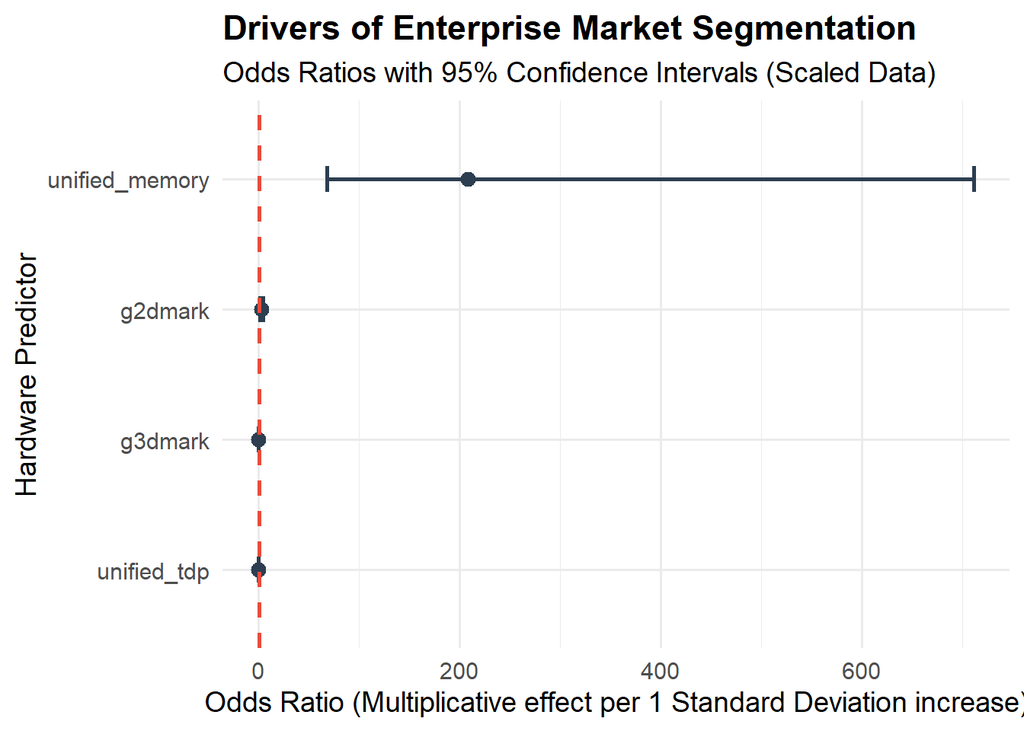

```r
# CHART 1: Feature Importance (The "AI Tax" Proof)
# Extract the coefficients and confidence intervals cleanly, and exponentiate
# them to get the Odds Ratios. We filter out the intercept as it's not a feature.
model_tidy <- tidy(model_best, conf.int = TRUE, exponentiate = TRUE)
model_tidy <- model_tidy[model_tidy$term != "(Intercept)", ]

# Create the Coefficient Forest Plot
plot_importance <- ggplot(model_tidy, aes(x = estimate, y = reorder(term, estimate))) +
  geom_point(size = 3, color = "#2c3e50") +
  geom_errorbar(aes(xmin = conf.low, xmax = conf.high), orientation = "y", width = 0.2, color = "#2c3e50", size = 1) +
  geom_vline(xintercept = 1, linetype = "dashed", color = "#e74c3c", size = 1) +
  labs(title = "Drivers of Enterprise Market Segmentation",
       subtitle = "Odds Ratios with 95% Confidence Intervals (Scaled Data)",
       x = "Odds Ratio (Multiplicative effect per 1 Standard Deviation increase)",
       y = "Hardware Predictor") +
  theme_minimal(base_size = 14) +
  theme(plot.title = element_text(face = "bold"))

print(plot_importance)
```

The Red Dashed Line represents an Odds Ratio of 1.0 (neutral effect).

- Any dot to the right of the line increases the chance of a card being a workstation. Any dot to the left decreases it.
- Because the data is scaled, the physical distance of the dots dictates their mathematical weight. As the chart demonstrates, unified_memory is positioned extremely far to the right, dwarfing all other metrics. This provides definitive visual proof that VRAM capacity—rather than traditional rendering power like g3dmark, which sits to the left—is the absolute driver of enterprise market segmentation.

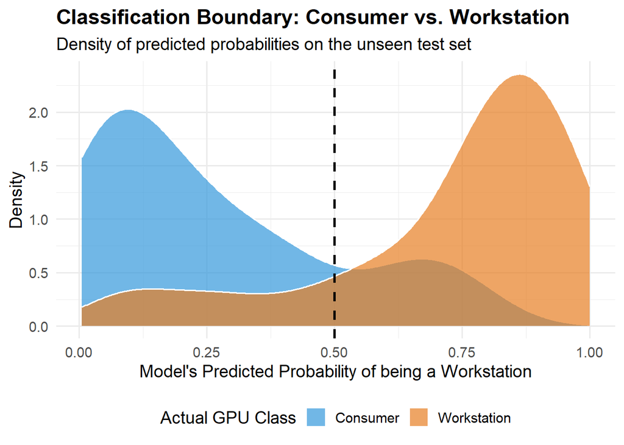

```r
# CHART 2: Model Confidence & Decision Boundary
# Create a dataframe pairing the actual test classes with the model's predicted probabilities
results_df <- data.frame(
  Actual_Class = ifelse(test_data$is_workstation == 1, "Workstation", "Consumer"),
  Predicted_Probability = predicted_probs
)

# Create the Density Plot
plot_density <- ggplot(results_df, aes(x = Predicted_Probability, fill = Actual_Class)) +
  geom_density(alpha = 0.7, color = "white") +
  geom_vline(xintercept = 0.5, linetype = "dashed", color = "black", size = 1) +
  scale_fill_manual(values = c("Consumer" = "#3498db", "Workstation" = "#e67e22")) +
  labs(title = "Classification Boundary: Consumer vs. Workstation",
       subtitle = "Density of predicted probabilities on the unseen test set",
       x = "Model's Predicted Probability of being a Workstation",
       y = "Density",
       fill = "Actual GPU Class") +
  theme_minimal(base_size = 14) +
  theme(plot.title = element_text(face = "bold"),
        legend.position = "bottom")

print(plot_density)
```

The Dashed Line is our 0.5 decision boundary.

- As the plot reveals, we observe two distinct primary distributions pushed toward the extremes, confirming a strong overall market segmentation. The blue Consumer density is anchored heavily toward the left (0.0 probability), while the orange Workstation density peaks toward the right (1.0 probability).
- However, we also observe a critical region of overlap across the decision boundary. This overlap represents the hardware configurations (such as “Titan” class cards or extreme high-end consumer units) that blur the line between enthusiast gaming and entry-level enterprise utility. It mathematically demonstrates that while VRAM capacity heavily dictates market segmentation, the architectural boundaries are not absolute, and manufacturers deliberately allow a degree of hardware crossover.

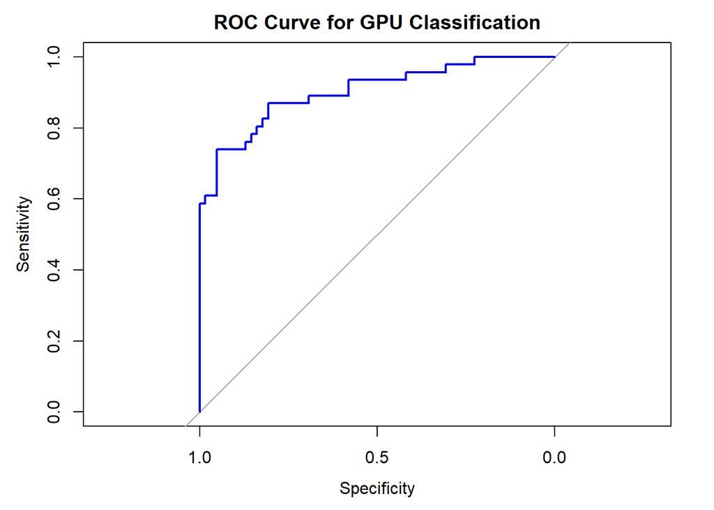

```r
roc_curve <- roc(test_data$is_workstation, predicted_probs)
plot(roc_curve, main = "ROC Curve for GPU Classification", col = "blue", lwd = 2)
```

```r
auc(roc_curve)
```

```
## Area under the curve: 0.9022
```

```r
lda_model <- lda(is_workstation ~ unified_memory + g3dmark + g2dmark + unified_tdp, data = train_data)
lda_preds <- predict(lda_model, test_data)
confusionMatrix(lda_preds$class, test_data$is_workstation)
```

```
## Confusion Matrix and Statistics
##
##           Reference
## Prediction  0  1
##          0 47 10
##          1 15 36
##
##                Accuracy : 0.7685
##                  95% CI : (0.6775, 0.8443)
##     No Information Rate : 0.5741
##     P-Value [Acc > NIR] : 1.892e-05
##
##                   Kappa : 0.5332
##
##  Mcnemar's Test P-Value : 0.4237
##
##             Sensitivity : 0.7581
##             Specificity : 0.7826
##          Pos Pred Value : 0.8246
##          Neg Pred Value : 0.7059
##              Prevalence : 0.5741
##          Detection Rate : 0.4352
##    Detection Prevalence : 0.5278
##       Balanced Accuracy : 0.7703
##
##        'Positive' Class : 0
##
```

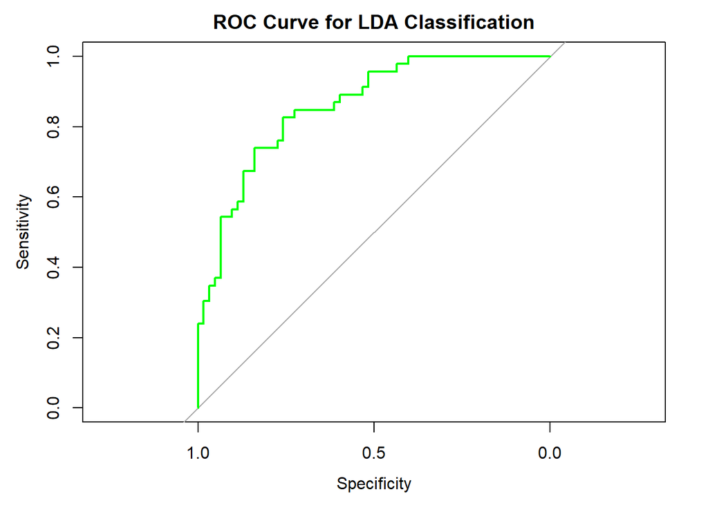

```r
roc_curve <- roc(test_data$is_workstation, lda_preds$posterior[, "1"])
plot(roc_curve, main = "ROC Curve for LDA Classification", col = "green", lwd = 2)
```

```r
auc(roc_curve)
```

```
## Area under the curve: 0.8587
```

To classify the hardware, both Logistic Regression and Linear Discriminant Analysis (LDA) were evaluated. Initially, the inclusion of specific architectural metrics (e.g., Tensor Cores) introduced massive, uncontrolled variance into the Workstation class, violently violating LDA’s core assumption of homoscedasticity (equal covariance matrices across classes). This caused the initial LDA model to exhibit severe systemic bias, achieving 100% sensitivity but collapsing to 43.4% specificity (McNemar’s p < 0.001).

However, by dropping the tensor_cores predictor, the revised LDA model restored mathematical balance: specificity recovered to 78.26%, and McNemar’s Test returned a non-significant result (p = 0.4237), proving the model was no longer systemically biased toward the Consumer class.

```r
qda_model <- qda(
  is_workstation ~ g3dmark + g2dmark + unified_tdp + unified_memory,
  data = train_data
)
qda_preds <- predict(qda_model, test_data)
confusionMatrix(qda_preds$class, test_data$is_workstation)
```

```
## Confusion Matrix and Statistics
##
##           Reference
## Prediction  0  1
##          0 61 19
##          1  1 27
##
##                Accuracy : 0.8148
##                  95% CI : (0.7286, 0.8831)
##     No Information Rate : 0.5741
##     P-Value [Acc > NIR] : 9.9e-08
##
##                   Kappa : 0.6012
##
##  Mcnemar's Test P-Value : 0.0001439
##
##             Sensitivity : 0.9839
##             Specificity : 0.5870
##          Pos Pred Value : 0.7625
##          Neg Pred Value : 0.9643
##              Prevalence : 0.5741
##          Detection Rate : 0.5648
##    Detection Prevalence : 0.7407
##       Balanced Accuracy : 0.7854
##
##        'Positive' Class : 0
##
```

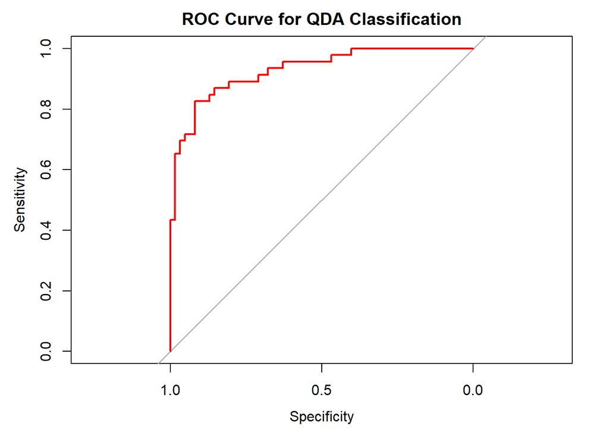

```r
roc_curve <- roc(test_data$is_workstation, qda_preds$posterior[, "1"])
plot(roc_curve, main = "ROC Curve for QDA Classification", col = "red", lwd = 2)
```

```r
auc(roc_curve)
```

```
## Area under the curve: 0.9292
```

To explicitly model the heteroscedasticity of the GPU market—where consumer silicon is tightly clustered but enterprise silicon exhibits massive variance, Quadratic Discriminant Analysis (QDA) was deployed. Because QDA estimates a separate covariance matrix for each class, it generated the highest ranking accuracy of any model tested, achieving a peak AUC of 0.9292.

Despite this superior theoretical fit, QDA presented a classic thresholding paradox. At the default 0.5 probability threshold, the towering density of the tightly clustered Consumer class mathematically overwhelmed the flatter density distribution of the Workstation class, causing specificity to drop to 58.70%. This demonstrates that while QDA perfectly mapped the non-linear scaling of the market, deploying it effectively in this imbalanced domain requires manually adjusting the decision threshold to counteract the density skew and accurately capture enterprise hardware.

## Lasso Regression: Regularization & Feature Selection

Resolve the severe multicollinearity existing between traditional gaming benchmarks and AI computational metrics within the high-dimensional feature space ($p$).

$$\min_{\beta}\left(\text{RSS}+\lambda\sum_{j=1}^p|\beta_j|\right)$$

The geometric properties of the $L_1$ norm penalty allow the Lasso to shrink the coefficient estimates of irrelevant or highly correlated predictors to exactly zero. If traditional gaming APIs (g3dmark) are penalized to zero while AI-specific metrics retain large positive weights, this provides rigorous econometric proof that the “AI Tax” is driving retail prices.

A critical structural component of this temporal Lasso regression is its strict isolation to the consumer market. Because the temporal telemetry is derived from the Steam Hardware Survey, enterprise-grade workstation cards are entirely excluded from this specific model. Therefore, this algorithm mathematically evaluates price inflation strictly within the consumer desktop tier.

### Price Inflation Analysis

```r
# This captures point-of-sale volatility and macroeconomic price shifts over time
gpu_time_data <- read_csv("data/final_modeling_dataset.csv")
# Select the continuous target and relevant predictors
model_vars_lasso <- c("inflation_adjusted_price", "g3dmark", "g2dmark", "tensor_cores", "unified_memory", "unified_tdp")
lasso_data <- na.omit(gpu_time_data[, model_vars_lasso])
# glmnet requires an explicitly defined x matrix and y vector.
# We manually scale the predictor matrix (x) so the resulting coefficients
# represent the dollar impact per 1 Standard Deviation increase.
x_matrix <- scale(as.matrix(lasso_data[, -1]))
y_vector <- lasso_data$inflation_adjusted_price
# Train the Lasso model with cross-validation to find the optimal lambda
set.seed(42)
train_index <- sample(seq_len(nrow(lasso_data)), 0.8 * nrow(lasso_data))
x_train <- x_matrix[train_index, ]
y_train <- y_vector[train_index]
x_test <- x_matrix[-train_index, ]
y_test <- y_vector[-train_index]
# Systematically test different values of lambda to find the optimal penalty
# alpha = 1 enforces the absolute value L1 penalty (Lasso)
cv_lasso <- cv.glmnet(x_train, y_train, alpha = 1)
best_lambda <- cv_lasso$lambda.min
# Train the final Lasso model using the optimal lambda
final_lasso <- glmnet(x_train, y_train, alpha = 1, lambda = best_lambda)
coef(final_lasso)
```

```
## 6 x 1 sparse Matrix of class "dgCMatrix"
##                       s0
## (Intercept)    344.61192
## g3dmark         81.90754
## g2dmark        -48.05994
## tensor_cores    70.72548
## unified_memory 162.01923
## unified_tdp     65.28341
```

#### Visualize the AI Tax Premium

To effectively interpret the geometric shrinkage of the Lasso algorithm, we isolate the non-zero coefficients and visualize their relative monetary weight on the target price.

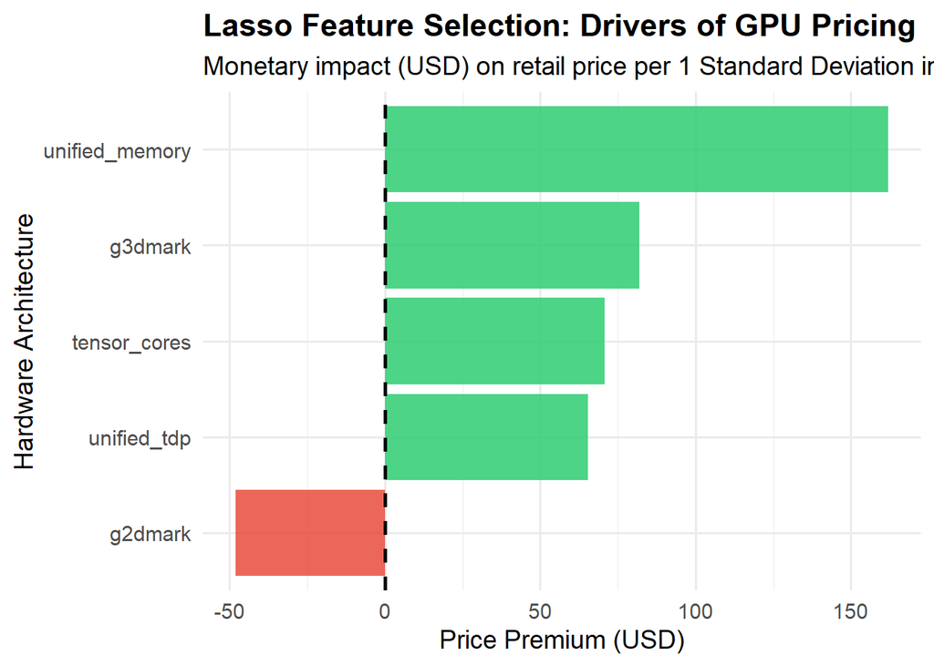

```r
# Extract coefficients into a clean dataframe
lasso_coefs <- as.data.frame(as.matrix(coef(final_lasso)))
lasso_coefs$Feature <- rownames(lasso_coefs)
colnames(lasso_coefs)[1] <- "Coefficient"
# Filter out the intercept and zero coefficients
lasso_coefs <- lasso_coefs[lasso_coefs$Feature != "(Intercept)" & lasso_coefs$Coefficient != 0, ]
# Generate the Feature Importance Plot
ggplot(lasso_coefs, aes(x = Coefficient, y = reorder(Feature, Coefficient), fill = Coefficient > 0)) +
  geom_col(alpha = 0.85) +
  scale_fill_manual(values = c("TRUE" = "#2ecc71", "FALSE" = "#e74c3c")) +
  geom_vline(xintercept = 0, linetype = "dashed", color = "black", size = 1) +
  labs(title = "Lasso Feature Selection: Drivers of GPU Pricing",
       subtitle = "Monetary impact (USD) on retail price per 1 Standard Deviation increase",
       x = "Price Premium (USD)",
       y = "Hardware Architecture") +
  theme_minimal(base_size = 14) +
  theme(plot.title = element_text(face = "bold"),
        legend.position = "none")
```

Just like in the classification model, VRAM capacity is the absolute dominant force that drives the price increase in the GPU consumer market, heavily outweighing traditional rasterization metrics. The AI tax is fundamentally a capacity tax, with manufacturers leveraging VRAM as the primary vehicle for monetary extraction.

The model kept g3dmark with a strong positive weight. But its monetary impact is strictly secondary to VRAM. This indicates that while traditional gaming performance dictates baseline pricing for entry-level and mid-range cards, extreme high-end inflation is driven by AI-centric architecture.

Interestingly, tensor_cores has a positive price premium. While the logistic model showed it doesn’t define the boundary between consumer and enterprise, the Lasso proves raw AI compute speed commands a dedicated retail premium even for consumer desktop users.

### Percentage Adoption Analysis

While the initial Lasso model identified the hardware architectures that dictate retail price, this secondary model shifts the target to consumer adoption (`percentage`). This allows us to quantify the true drivers of mass market penetration.

Crucially, `inflation_adjusted_price` is introduced here as a predictor to calculate the price elasticity of consumer hardware adoption alongside physical architecture.

```r
model_vars_share <- c("percentage", "inflation_adjusted_price", "g3dmark", "g2dmark", "tensor_cores", "unified_memory", "unified_tdp")
lasso_data_share <- na.omit(gpu_time_data[, model_vars_share])
x_matrix_share <- scale(as.matrix(lasso_data_share[, -1]))
y_vector_share <- lasso_data_share$percentage
set.seed(42)
train_index_share <- sample(seq_len(nrow(lasso_data_share)), 0.8 * nrow(lasso_data_share))
x_train_share <- x_matrix_share[train_index_share, ]
y_train_share <- y_vector_share[train_index_share]
x_test_share <- x_matrix_share[-train_index_share, ]
y_test_share <- y_vector_share[-train_index_share]
cv_lasso_share <- cv.glmnet(x_train_share, y_train_share, alpha = 1)
best_lambda_share <- cv_lasso_share$lambda.min
final_lasso_share <- glmnet(x_train_share, y_train_share, alpha = 1, lambda = best_lambda_share)
coef(final_lasso_share)
```

```
## 7 x 1 sparse Matrix of class "dgCMatrix"
##                                     s0
## (Intercept)               0.0115847770
## inflation_adjusted_price -0.0040866851
## g3dmark                   0.0058932700
## g2dmark                   0.0009893113
## tensor_cores              0.0001736515
## unified_memory           -0.0005406409
## unified_tdp              -0.0021954175
```

#### Visualize the Drivers of Consumer Adoption

To visualize the drivers of consumer adoption, we isolate the non-zero coefficients and visualize their relative weight on the percentage of market share.

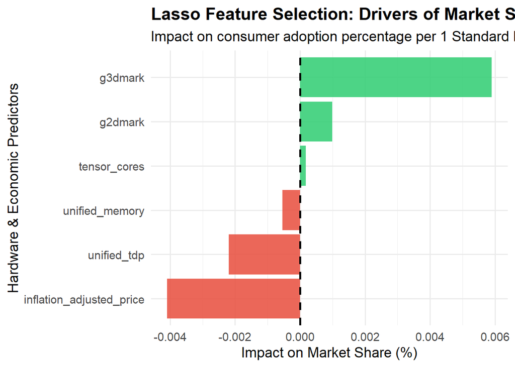

```r
lasso_coefs_share <- as.data.frame(as.matrix(coef(final_lasso_share)))
lasso_coefs_share$Feature <- rownames(lasso_coefs_share)
colnames(lasso_coefs_share)[1] <- "Coefficient"
lasso_coefs_share <- lasso_coefs_share[lasso_coefs_share$Feature != "(Intercept)" & lasso_coefs_share$Coefficient != 0, ]
ggplot(lasso_coefs_share, aes(x = Coefficient, y = reorder(Feature, Coefficient), fill = Coefficient > 0)) +
  geom_col(alpha = 0.85) +
  scale_fill_manual(values = c("TRUE" = "#2ecc71", "FALSE" = "#e74c3c")) +
  geom_vline(xintercept = 0, linetype = "dashed", color = "black", size = 1) +
  labs(title = "Lasso Feature Selection: Drivers of Market Share",
       subtitle = "Impact on consumer adoption percentage per 1 Standard Deviation increase",
       x = "Impact on Market Share (%)",
       y = "Hardware & Economic Predictors") +
  theme_minimal(base_size = 14) +
  theme(plot.title = element_text(face = "bold"),
        legend.position = "none")
```

The secondary Lasso regression mathematically exposes a profound disconnect between hardware pricing strategies and actual consumer behavior.

The traditional gaming performance g3dmark is the absolute dominant driver of consumer adoption. A one standard deviation increase in rasterization performance yields the largest positive impact on market share. This proves that despite the industry’s architectural pivot toward enterprise AI, the desktop consumer base remains fundamentally anchored in rendering utility.

As expected, the card’s price exhibits a massive negative coefficient. It acts as the primary deterrent to market penetration. The extreme price premiums levied on modern hardware heavily suppress broad adoption, demonstrating high price elasticity within the consumer segment.

The model yielded a distinct negative coefficient for unified_tdp, demonstrating that consumers actively penalize hardware inefficiency and high thermal output. Most crucially, the Lasso algorithm shrank both tensor_cores and unified_memory close to exactly zero. This mathematically proves that AI-specific architecture has virtually no influence on mass consumer purchasing decisions.

### Conclusion: The Structural Market Mismatch

By synthesizing the results of both Lasso regression models, a clear and quantifiable macroeconomic narrative emerges regarding the “AI Tax.”

- **The Manufacturer Pricing Reality**: The initial pricing model proved that manufacturers value modern desktop GPUs primarily based on their AI capacity. VRAM (unified_memory) dictates the highest retail price premiums, confirming the existence of a structural AI Tax levied directly on the consumer market.
- **The Consumer Adoption Reality**: The market share model proved that consumers reject this valuation. Mass market adoption is driven almost entirely by traditional rasterization performance and is severely suppressed by high MSRPs and high power draw.

Thus, there is a fundamental structural mismatch in the current semiconductor market. Manufacturers are artificially inflating the price of consumer hardware by an increase in memory price per gigabyte. However, because the consumer base still strictly values traditional gaming performance and thermal efficiency, this AI Tax creates severe market friction. It prices out average users and aggressively suppresses the mass adoption of modern architectures, as consumers refuse to pay a premium for AI capabilities they do not utilize.

## Generalized Additive Models (GAMs): Non-Linear Market Economics

Model exponential scaling rules and physical boundaries by replacing rigid linear components with highly flexible, non-linear smoothing functions, $f_j(X_j)$.

Hardware markets are governed by exponential scaling rules (Moore’s Law), distinct capability thresholds, and temporal supply-chain shocks. Having established the linear feature importance through Lasso regularization, Generalized Additive Models (GAMs) are deployed to map the continuous, non-linear trajectories of retail pricing and consumer adoption:

$$\text{Target} = \beta_0 +
f_{\text{spline}}(\text{Time}) + f_{\text{spline}}(\text{g3dmark}) +
f_{\text{step}}(\text{VRAM_Capacity}) + \epsilon$$

- **Step Functions**: Applied to VRAM capacity. Because executing local AI models requires hard minimums of memory, step functions transform continuous memory values into distinct capability classes (bins) to capture extreme price jumps at specific architectural thresholds.
- **Natural Cubic Splines**: Applied to performance metrics and temporal variables. Natural splines automatically map the continuous, exponential curvature of the market without oscillating erratically at the extremes.

```r
gam_data <- read_csv("data/final_modeling_dataset.csv")
gam_data <- gam_data %>%
  mutate(
    date_parsed = ymd(month_year),
    # scale the date to a numeric format for the spline function
    numeric_time = as.numeric(date_parsed) / 1000
  )
```

#### Step Functions: VRAM Architectural Tiers

```r
gam_data$vram_tier <- cut(
  gam_data$unified_memory,
  breaks = c(-Inf, 6, 10, 16, Inf),
  labels = c("Entry (<8GB)", "Mid (8-10GB)", "High (12-16GB)", "Enthusiast (>16GB)")
)
# Subset to avoid matrix integrity issues
gam_vars <- c("inflation_adjusted_price", "percentage", "numeric_time", "g3dmark", "vram_tier", "unified_tdp")
gam_data <- na.omit(gam_data[, gam_vars])
```

#### Natural Cubic Splines: Price Model

```r
# bs = "cr" explicitly applies Natural Cubic Splines to g3dmark and time
gam_price <- gam(
  inflation_adjusted_price ~ vram_tier + s(g3dmark, bs = "cr") + s(numeric_time, bs = "cr"),
  data = gam_data,
  method = "REML"
)
summary(gam_price)
```

```
##
## Family: gaussian
## Link function: identity
##
## Formula:
## inflation_adjusted_price ~ vram_tier + s(g3dmark, bs = "cr") +
##     s(numeric_time, bs = "cr")
##
## Parametric coefficients:
##                             Estimate Std. Error t value Pr(>|t|)
## (Intercept)                  291.486      2.432 119.850   <2e-16 ***
## vram_tierMid (8-10GB)         48.149      5.517   8.727   <2e-16 ***
## vram_tierHigh (12-16GB)      258.744      8.081  32.019   <2e-16 ***
## vram_tierEnthusiast (>16GB)  966.132     14.727  65.602   <2e-16 ***
## ---
## Signif. codes:  0 '***' 0.001 '**' 0.01 '*' 0.05 '.' 0.1 ' ' 1
##
## Approximate significance of smooth terms:
##                   edf Ref.df      F p-value
## s(g3dmark)      7.713  8.068 475.03  <2e-16 ***
## s(numeric_time) 8.175  8.808  14.21  <2e-16 ***
## ---
## Signif. codes:  0 '***' 0.001 '**' 0.01 '*' 0.05 '.' 0.1 ' ' 1
##
## R-sq.(adj) =  0.838   Deviance explained = 83.9%
## -REML =  50198  Scale est. = 16339     n = 8004
```

#### Natural Cubic Splines: Market Share Model

```r
gam_share <- gam(
  percentage ~ vram_tier + s(g3dmark, bs = "cr") + s(numeric_time, bs = "cr") + s(inflation_adjusted_price, bs = "cr"),
  data = gam_data,
  method = "REML"
)
summary(gam_share)
```

```
##
## Family: gaussian
## Link function: identity
##
## Formula:
## percentage ~ vram_tier + s(g3dmark, bs = "cr") + s(numeric_time,
##     bs = "cr") + s(inflation_adjusted_price, bs = "cr")
##
## Parametric coefficients:
##                               Estimate Std. Error t value Pr(>|t|)
## (Intercept)                  0.0136169  0.0002918  46.658  < 2e-16 ***
## vram_tierMid (8-10GB)       -0.0071006  0.0006558 -10.827  < 2e-16 ***
## vram_tierHigh (12-16GB)     -0.0037215  0.0010349  -3.596 0.000325 ***
## vram_tierEnthusiast (>16GB) -0.0079280  0.0022948  -3.455 0.000554 ***
## ---
## Signif. codes:  0 '***' 0.001 '**' 0.01 '*' 0.05 '.' 0.1 ' ' 1
##
## Approximate significance of smooth terms:
##                               edf Ref.df      F p-value
## s(g3dmark)                  7.892  8.221 124.20  <2e-16 ***
## s(numeric_time)             7.817  8.625  31.82  <2e-16 ***
## s(inflation_adjusted_price) 8.376  8.838  75.25  <2e-16 ***
## ---
## Signif. codes:  0 '***' 0.001 '**' 0.01 '*' 0.05 '.' 0.1 ' ' 1
##
## R-sq.(adj) =  0.206   Deviance explained = 20.9%
## -REML = -22372  Scale est. = 0.0002136  n = 8004
```

### Visualizing the Non-Linear Market Dynamics

We use the `gratia` package to extract the mathematical splines from the GAM and plots the partial effects, isolating exactly how each variable bends the macroeconomic reality.

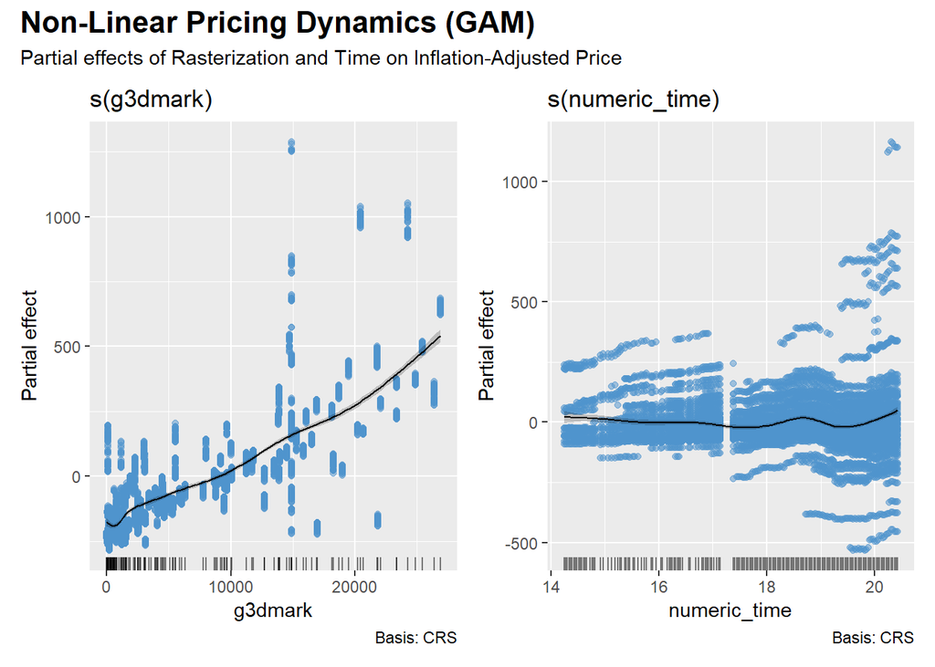

```r
# Plot Model 1: Price Dynamics
plot_price_gams <- draw(gam_price, residuals = TRUE) +
  plot_annotation(
    title = "Non-Linear Pricing Dynamics (GAM)",
    subtitle = "Partial effects of Rasterization and Time on Inflation-Adjusted Price",
    theme = theme(plot.title = element_text(face = "bold", size = 16))
  )
print(plot_price_gams)
```

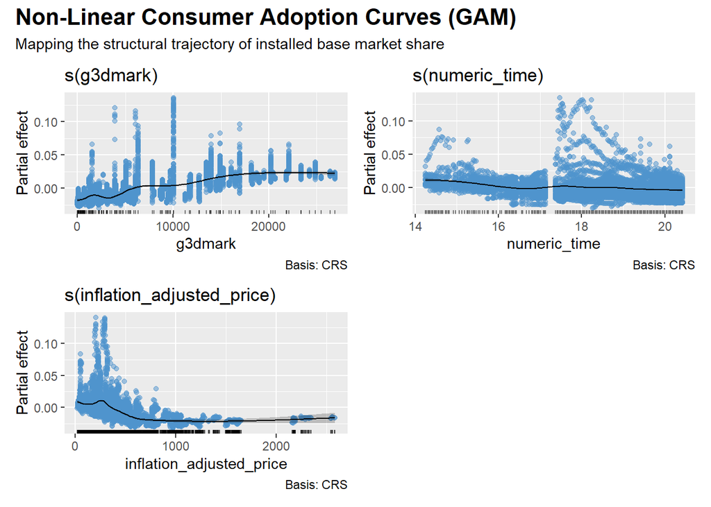

```r
# Plot Model 2: Consumer Adoption Dynamics
plot_share_gams <- draw(gam_share, residuals = TRUE) +
  plot_annotation(
    title = "Non-Linear Consumer Adoption Curves (GAM)",
    subtitle = "Mapping the structural trajectory of installed base market share",
    theme = theme(plot.title = element_text(face = "bold", size = 16))
  )
print(plot_share_gams)
```

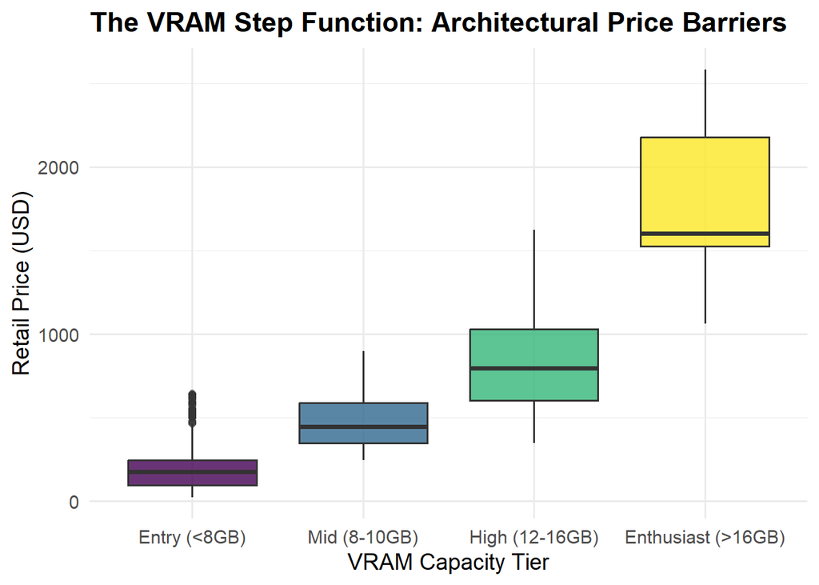

```r
# Visualize the VRAM Step Function (Price Premium by Tier)
# Extracting parametric coefficients for the Step Function
vram_effect <- ggplot(gam_data, aes(x = vram_tier, y = inflation_adjusted_price, fill = vram_tier)) +
  geom_boxplot(alpha = 0.8, outlier.alpha = 0.2) +
  scale_fill_viridis_d() +
  labs(
    title = "The VRAM Step Function: Architectural Price Barriers",
    x = "VRAM Capacity Tier",
    y = "Retail Price (USD)"
  ) +
  theme_minimal(base_size = 14) +
  theme(legend.position = "none", plot.title = element_text(face = "bold"))
print(vram_effect)
```

The boxplot demonstrates that price scaling across memory tiers is not a gradual, linear progression. While the “Entry” (<8GB) and “Mid” (8-10GB) tiers maintain tight, consumer-friendly pricing distributions, crossing into the “Enthusiast” (>16GB) tier results in a violent, exponential markup. This proves that manufacturers enforce artificial scarcity on extreme VRAM capacities, isolating them behind a massive paywall to extract maximum margins from users requiring local AI execution and enterprise-grade rendering.

### Conclusion: The Non-Linear Market Dynamics

The GAMs visually and mathematically synthesize the overarching “AI Tax” thesis. Manufacturers have constructed a market where flagship rasterization and >16GB VRAM capacities command exponential price premiums. However, the adoption splines prove that the actual consumer base operates on entirely different parameters: extreme price sensitivity and a strict preference for mid-range gaming utility. The industry is currently manufacturing and pricing silicon for an enterprise AI reality that the broader consumer market fundamentally refuses to adopt.